# Earnin - Data Assignment

Required Packages + Load Data into a SQLite database

```r
require(RSQLite)
require(XLConnect)
```

[output not shown]

```r
require(dplyr)
```

```r
require(ggplot2)
location_csv <- "/Users/neilbhatt/Documents/Earnin/AssessmentData/"
db <- dbConnect(SQLite(), dbname="Earnin.sqlite")
dbWriteTable(conn=db, name = "attribution", value=paste0(location_csv,"attribution.csv"))
dbWriteTable(conn=db, name = "device", value=paste0(location_csv,"device.csv"))
dbWriteTable(conn=db, name = "item", value=paste0(location_csv,"item.csv"))
dbWriteTable(conn=db, name = "sale", value=paste0(location_csv,"sale.csv"))
dbWriteTable(conn=db, name = "user_device", value=paste0(location_csv,"user_device.csv"))
dbWriteTable(conn=db, name = "user", value=paste0(location_csv,"user.csv"))
```

0. If you were about to start working with this data in a business context, what else would you want to know about it before getting started, besides the schema attached? What would you ask me if I dumped it on your desk and asked you to answer some questions based on it?

• What is the source of the data? • What are the chances of misrecorded data and are you already aware of any dates or times in which the system failed to capture data points?  
• Business case, is there a hypothesis in mind? • Are you looking to identify time series trends? Are there any time frames to particularly analyze?

## 1. Attribution

1. What can you tell me about the relationship between users and devices? Does it seem like a relationship that would happen in the real world?

• I would generally expect users to each have 1-2 devices (generally tablet & mobile) being used in a small time period? Look at a Time period based on current user usage rates.

SQL Pull

```r
device <- dbGetQuery(db,
  "SELECT a.user_id, count(a.device_id) as Device, count(distinct a.device_type) as Device_Type,
   count(distinct operating_system) as OS
   FROM
    (SELECT a.user_id, a.device_id, b.device_type, b.operating_system
    FROM user_device a
    JOIN device b on a.device_id = b.id
    GROUP BY 1,2,3) a
   GROUP BY 1
   ORDER BY 2,3")
device$diff <- device$Device - device$Device_Type
device$diff_OS <- device$Device - device$OS
summary(device$Device)
```

```
##    Min. 1st Qu.  Median    Mean 3rd Qu.    Max.
##   1.000   1.000   1.000   1.091   1.000   4.000
```

Summary meets expectations, but with the mean slightly skewed and a max point of 4, I graph to identify outliers.

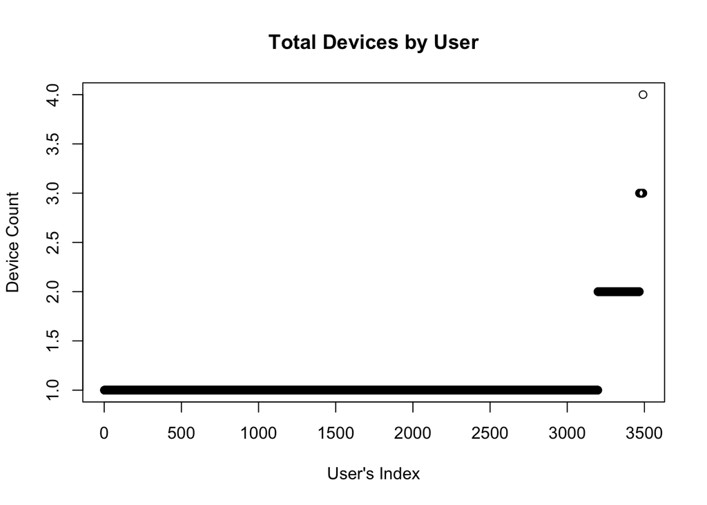

```r
plot(device$Device, main="Total Devices by User", xlab="User's Index", ylab="Device Count")
```

It seems unusual for users to have more than 2 devices or devices of the same type and operating system.

```r
device_sub <- subset(device, device$diff_OS>0)
device_sub
```

```
##      user_id Device Device_Type OS diff diff_OS
## 3200      88      2           1  1    1       1
## 3203     146      2           1  1    1       1
## 3209     399      2           1  1    1       1
## 3212     451      2           1  1    1       1
## 3214     597      2           1  1    1       1
## 3215     619      2           1  1    1       1
## 3217     730      2           1  1    1       1
## 3234    1323      2           1  1    1       1
## 3237    1401      2           1  1    1       1
## 3239    1561      2           1  1    1       1
## 3241    1603      2           1  1    1       1
## 3242    1605      2           1  1    1       1
## 3243    1614      2           1  1    1       1
## 3251    1813      2           1  1    1       1
```

[output cut: 22 more lines]

There are 36 Users that have more than 1 device with the same operating system that should be looked into a bit further since they could be problematic or fraudulent.

Having a variable that identifies whether the device is a mobile or tablet device would be convenient and reduce the number of users to manually analyze.

```r
num_devices <- dbGetQuery(db,
  "SELECT a.device_id as Device, count(distinct a.user_id) as user_count
   FROM user_device a
   GROUP BY 1
   ORDER BY 2 desc")

num_devices %>% group_by(user_count)%>%tally(sort = TRUE)
```

```
## # A tibble: 2 x 2
##   user_count     n
##        <int> <int>
## 1          1  3217
## 2          2   296
```

There are 296 devices that are attributed to 2 users, which doesn’t appear to be out of the norm on face value given husband/wife or significant other combinations using a common device. However, verifying user addresses, place of employment, or alternative fields would help mitigate risk more.

2. What campaign was responsible for each user’s finding our app? Please describe how you decided what logic to use and provide both the implementation of that logic and the answer as output.

Assumption: Finding app for the first time Data Pull: userid, first touch campaign date and the associated campaign Where clause to not include users that had a registered device before seeing a campaign.  
First touch campaign seemed most appropriate since this is the first time that a user has discovered the app.

```r
Find_All <- dbGetQuery(db,
"SELECT DISTINCT b.user_id, min(a.created_on) AS ft_campaign, a.campaign
  FROM attribution a
  JOIN user_device b ON b.device_id = a.device_id
  JOIN (SELECT b.user_id, min(a.created_on) AS ft_date
        FROM attribution a
        JOIN user_device b ON b.device_id = a.device_id
        GROUP BY 1) c ON c.user_id = b.user_id
WHERE a.created_on <= c.ft_date
GROUP BY 1,3
")

Find <- dbGetQuery(db,
"SELECT DISTINCT b.user_id, min(a.created_on) AS ft_campaign, a.campaign
  FROM attribution a
  JOIN user_device b ON b.device_id = a.device_id
  JOIN (SELECT b.user_id, min(a.created_on) AS ft_date
        FROM attribution a
        JOIN user_device b ON b.device_id = a.device_id
        GROUP BY 1) c ON c.user_id = b.user_id
  JOIN device d ON d.id = b.device_id
WHERE a.created_on <= c.ft_date
AND d.created_on > c.ft_date
GROUP BY 1,3
")
```

There are 2,651 users in the attribution table, however 887 users had a device already registered a device before a campaign.

```r
library(dplyr)
FT_Campaigns <- Find %>% group_by(campaign)%>%tally(sort = TRUE)
FT_Campaigns
```

```
## # A tibble: 100 x 2
##    campaign     n
##       <chr> <int>
##  1   5IHLGC    31
##  2   MOTVAN    31
##  3   FE91LN    28
##  4   83RCJF    27
##  5   ZZGRSM    27
##  6   0837KH    25
##  7   HLWXVF    25
##  8   1BRIGC    24
##  9   6HBW2A    24
## 10   WL07ZB    24
## # ... with 90 more rows
```

Table outlines number of new users generated by each campaign.

3. Which campaign was responsible for each sale? Same output as 1.2.

Data Pull:

```r
Sale_Campaign <- dbGetQuery(db,
"SELECT a.user_id, a.sales_id, a.sale_dt AS sale_date, a.amount, b.campaign, b.created_on AS campaign_dt
FROM attribution b
JOIN user_device d on b.device_id = d.device_id
JOIN (SELECT a.user_id, a.created_on as sale_dt, a.id AS sales_id,a.amount
  FROM sale a
  GROUP BY 1,2,3,4) a ON a.user_id = d.user_id
GROUP BY 1,2,3,4,5,6")
Sale_Campaign$campaign_dt<- as.Date(Sale_Campaign$campaign_dt, '%m/%d/%y %H:%M')
Sale_Campaign$sale_date <- as.Date(Sale_Campaign$sale_date, '%Y-%m-%d %H:%M:%OS')
Sale_Campaign$days_to_sale <- Sale_Campaign$sale_date - Sale_Campaign$campaign_dt
Sale_Campaign <- subset(Sale_Campaign, Sale_Campaign$days_to_sale >= 0)

g1 <- Sale_Campaign %>% group_by(campaign) %>% summarise(mean = mean(days_to_sale), median = median(days_to_sale), min(days_to_sale), max(days_to_sale)) %>% arrange((mean))
```

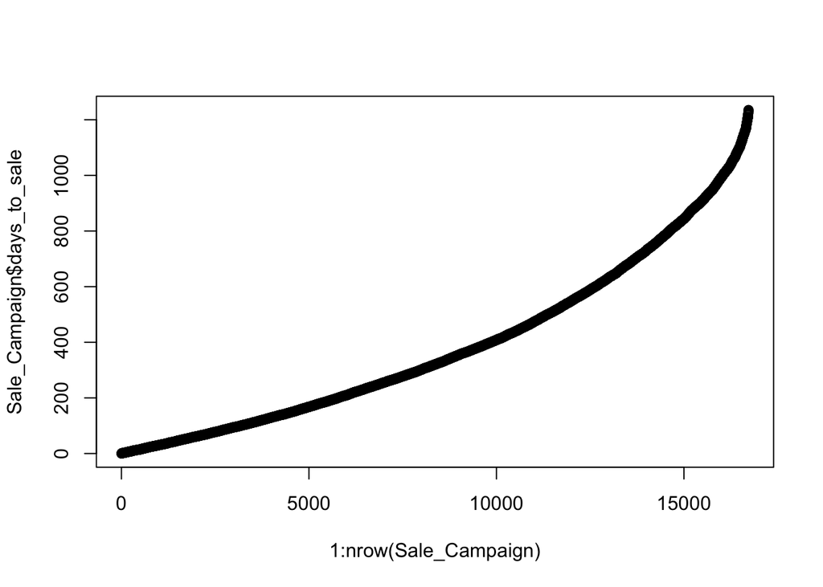

```r
Sale_Campaign <- Sale_Campaign[order(Sale_Campaign$days_to_sale),]
plot(x=1:nrow(Sale_Campaign), y=Sale_Campaign$days_to_sale)
```

Large amount of outliers with some campaigns potentially creating sales >1200 days later

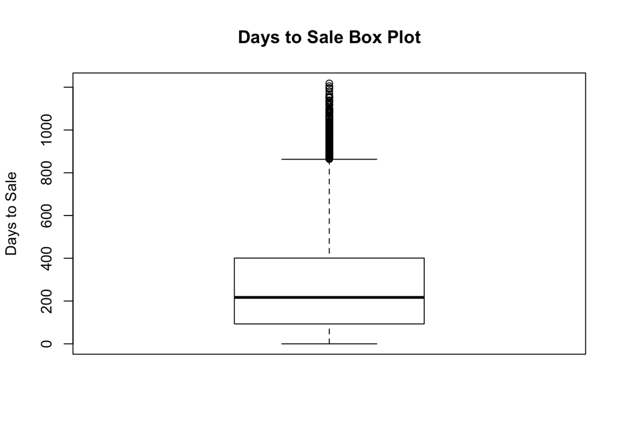

```r
tt <- table(Sale_Campaign$sales_id)
Sale_Campaign_1 <- subset(Sale_Campaign, Sale_Campaign$sales_id %in% names(tt[tt == 1]))
Boxplot <- boxplot(as.numeric(Sale_Campaign_1$days_to_sale), main="Days to Sale Box Plot", ylab="Days to Sale")
```

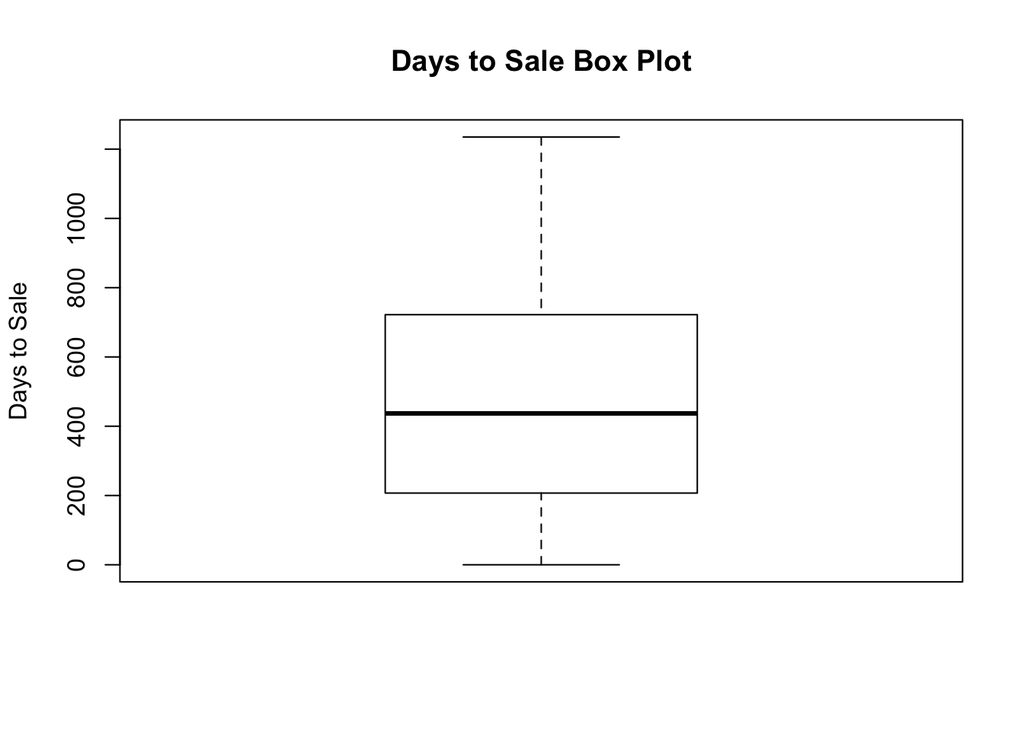

```r
Sale_Campaign_2 <- subset(Sale_Campaign,!(Sale_Campaign$sales_id %in% Sale_Campaign_1$sales_id))
Sale_Campaign_2 <- Sale_Campaign_2[order(Sale_Campaign_2$days_to_sale),]
Boxplot <- boxplot(as.numeric(Sale_Campaign_2$days_to_sale), main="Days to Sale Box Plot", ylab="Days to Sale")
```

Identifying a reasonable time frame for which a campaign should get credit for a sale is a difficult task. Especially for a product that is used in emergency-esq situations. However, under the assumption that the sales are effected by all campaigns that a user touches. I regorganize the data to provide path, total number of conversions, and total monetary value.

7,455 sales occured by touching only 1 campaign, 9,268 sales occured by touching more than one campaign.

```r
library(reshape2)
Sale_Campaign_org <- Sale_Campaign[order(Sale_Campaign$sales_id, Sale_Campaign$campaign_dt),]
Sale_Campaign_org <- Sale_Campaign_org %>% group_by(sales_id) %>% mutate(ida = row_number())
Sale_Campaign_wide <- data.frame(Sale_Campaign_org$sales_id,Sale_Campaign_org$campaign, Sale_Campaign_org$ida)
names(Sale_Campaign_wide) <- c('sales_id','campaign','id')
Sale_Campaign_wide <- melt(Sale_Campaign_wide, id.vars = c("sales_id","id"))
Sale_Campaign_wide <- dcast(Sale_Campaign_wide, sales_id ~ id)
Sales <- dbGetQuery(db, "SELECT a.id AS sales_id,a.amount FROM sale a GROUP BY 1,2")
Sales <- merge(Sale_Campaign_wide, Sales, by = 'sales_id')
Sales[is.na(Sales)] <- 0
Sales$path <- paste(Sales$`1`, Sales$`2`, Sales$`3`, Sales$`4`, Sales$`5`, Sales$`6`,Sales$`7`,Sales$`8`,Sales$`9`,Sales$`10`,Sales$`11`,Sales$`12`,Sales$`13`,sep=">")
Sales_Table <- Sales %>% group_by(path)%>%summarise(amount = sum(amount))
Sales_Table_2 <- Sales %>% group_by(path)%>%tally(sort = TRUE)
Sales_Table <- merge(Sales_Table, Sales_Table_2, by = 'path')
names(Sales_Table) <- c('path','total_conversion_value','total_conversions')
```

Sale touches a maximum of 13 campaigns and a minimum of 1 campaign.

Creating attribution model

```r
library(ChannelAttribution)
library(reshape)
```

```r
library(ggplot2)

H <- heuristic_models(Sales_Table, 'path', 'total_conversions', var_value='total_conversion_value')
M <- markov_model(Sales_Table, 'path', 'total_conversions', var_value='total_conversion_value', order = 1)
R <- merge(H, M, by='channel_name')
colnames(R)[1] <- "campaign"
R
```

```
##     campaign first_touch_conversions first_touch_value
## 1                                  0              0.00
## 2          0                       0              0.00
## 3      0837K                     154         119282.45
## 4      0IBF6                      85          66561.21
## 5      15R3D                      42          26074.98
## 6      1BRIG                     162         176176.92
## 7      1LYW4                     107          68221.08
## 8      1TNQY                      97          69871.86
## 9      1TZQD                     107          64386.93
## 10     1UV5W                      47          33716.53
## 11     1ZDQF                     115          88805.89
## 12     2IIPK                      91          46152.79
## 13     3DNOO                      90          62873.91
## 14     3J5HI                     119          52641.82
```

[output cut: 297 more lines]

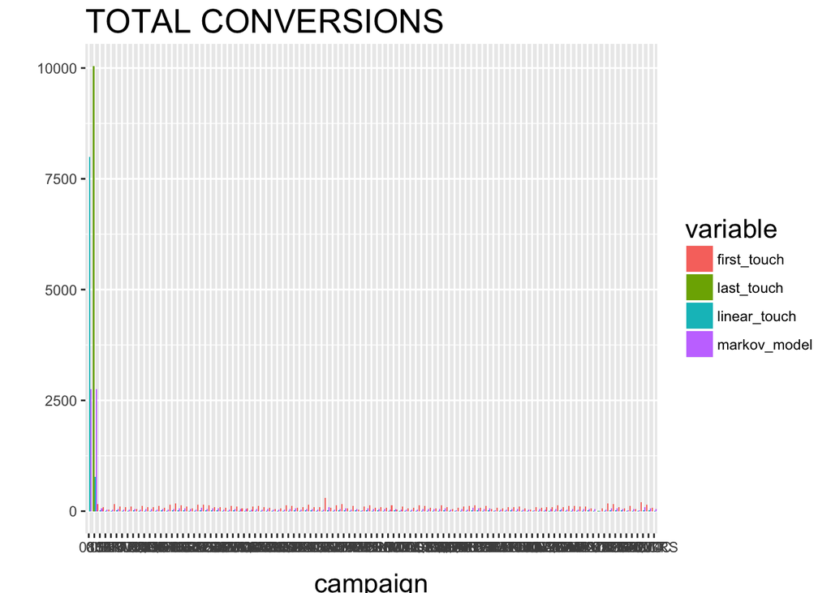

```r
R1 <- R[, (colnames(R)%in%c('campaign', 'first_touch_conversions', 'last_touch_conversions', 'linear_touch_conversions', 'total_conversion'))]
colnames(R1) <- c('campaign', 'first_touch', 'last_touch', 'linear_touch', 'markov_model')
R1 <- melt(R1, id='campaign')

ggplot(R1, aes(campaign, value, fill = variable)) +
  geom_bar(stat='identity', position='dodge') +
  ggtitle('TOTAL CONVERSIONS') +
  theme(axis.title.x = element_text(vjust = -2)) +
  theme(axis.title.y = element_text(vjust = +2)) +
  theme(title = element_text(size = 16)) +
  theme(plot.title=element_text(size = 20)) +
  ylab("")
```

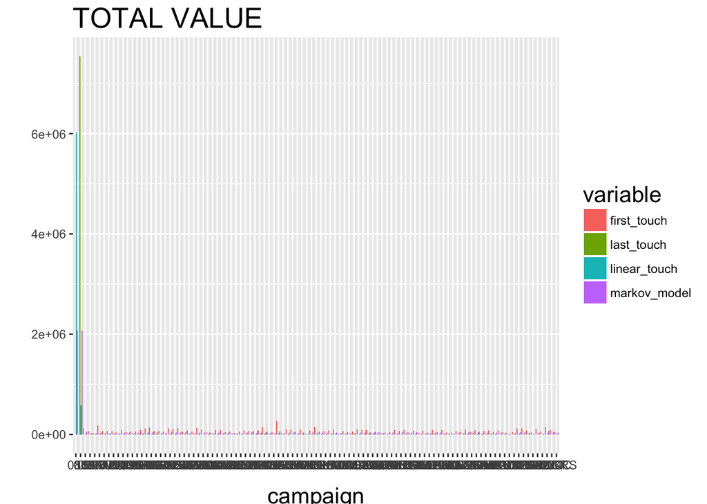

```r
R2 <- R[, (colnames(R)%in%c('campaign', 'first_touch_value', 'last_touch_value', 'linear_touch_value', 'total_conversion_value'))]

colnames(R2) <- c('campaign', 'first_touch', 'last_touch', 'linear_touch', 'markov_model')

R2 <- melt(R2, id='campaign')

ggplot(R2, aes(campaign, value, fill = variable)) +
  geom_bar(stat='identity', position='dodge') +
  ggtitle('TOTAL VALUE') +
  theme(axis.title.x = element_text(vjust = -2)) +
  theme(axis.title.y = element_text(vjust = +2)) +
  theme(title = element_text(size = 16)) +
  theme(plot.title=element_text(size = 20)) +
  ylab("")
```

4. Is there a better way that we could have collected or structured data to make our attribution analysis easier?

Having the path data for each sale from the beginning would make the attribution analysis easier. Also having channel instead of campaign may provide a better breakdown as to how users are finding the app and which channels are the most effective.

[output not shown]

3. It looks like sales have been a bit low the last couple of days of the sales data set. Is this something we should be worried about? Please use some statistics and describe what your answer means.

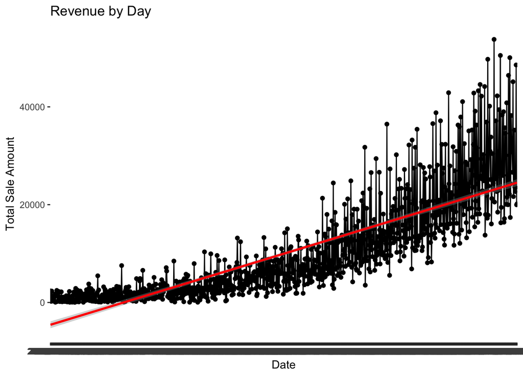

```r
sale_time <- dbGetQuery(db, "SELECT date(a.created_on) as sale_dt, count(a.id) AS sale_count, sum(a.amount) AS Total_Amount
                        FROM sale a
                        GROUP BY 1
                        ORDER BY 1 asc")

REV_plot <- ggplot(data=sale_time, aes(x=sale_dt, y=Total_Amount, group=1)) +
  geom_point(stat="identity", fill="steelblue") + geom_line() +
  xlab('Date') + ylab('Total Sale Amount') +ggtitle("Revenue by Day") + geom_smooth(method = "gam",colour='red')
REV_plot
```

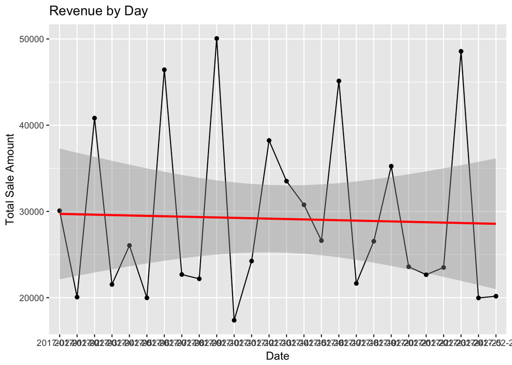

```r
sale_time_1 <- subset(sale_time, sale_time$sale_dt>='2017-02-01')
REV_plot_1 <- ggplot(data=sale_time_1, aes(x=sale_dt, y=Total_Amount, group=1)) +
  geom_point(stat="identity", fill="steelblue") + geom_line() +
  xlab('Date') + ylab('Total Sale Amount') +ggtitle("Revenue by Day") + geom_smooth(method = "gam",colour='red')
REV_plot_1
```

```r
library(readxl)
Earnin_MoM <- read_excel("~/Desktop/Earnin MoM.xlsx")
summary(Earnin_MoM$`MoM orders`)
```

```
##     Min.  1st Qu.   Median     Mean  3rd Qu.     Max.
## -0.24444 -0.04599  0.04520  0.05952  0.13432  0.48387
```

```r
summary(Earnin_MoM$`MoM total amount`)
```

```
##     Min.  1st Qu.   Median     Mean  3rd Qu.     Max.
## -0.62860 -0.15238 -0.04245  0.07687  0.32291  1.26117
```

```r
summary(Earnin_MoM$`MoM average transaction`)
```

```
##     Min.  1st Qu.   Median     Mean  3rd Qu.     Max.
## -0.56670 -0.20293  0.05864  0.03565  0.16474  1.35538
```

Looking at the last week alone:

```r
Earnin_last_week <- subset(Earnin_MoM, Earnin_MoM$date>'2017-02-19')
summary(Earnin_last_week$`MoM orders`)
```

```
##      Min.   1st Qu.    Median      Mean   3rd Qu.      Max.
## -0.172414 -0.037269  0.000000 -0.002511  0.050585  0.128205
```

```r
summary(Earnin_last_week$`MoM total amount`)
```

```
##      Min.   1st Qu.    Median      Mean   3rd Qu.      Max.
## -0.302197 -0.232804 -0.157417 -0.006436  0.216223  0.447725
```

```r
summary(Earnin_last_week$`MoM average transaction`)
```

```
##     Min.  1st Qu.   Median     Mean  3rd Qu.     Max.
## -0.31737 -0.22356 -0.11187  0.01089  0.10161  0.74933
```